# CSI-1-Prestige

Walter J.T.V

2024-10-07

# Exercise

## Libraries

```r
library(AER)
library(FactoMineR)
library(car)
library(mice)
library(missMDA)
library(EnvStats) # For variance tests
```

Response to study: prestige of occupation.

Firstly, create a new factor, dichotomy, indicating if an occupation refers to professional and managerial duties or not. Afterwards, answer the following questions, using graphical and inferential tools.

1. Does prestige seem to be normally distributed?
2. Calculate a 95% CI for prestige mean.
3. Calculate a 95% CI for prestige variance.
4. Does the dispersion of prestige depend on the type of occupation? Or on having professional/managerial profile? Formulate and quantify pvalues for testing group variances.
5. How would you test whether the prestige between blue and white collar occupations significantly differ or not?
6. Use condes() in FactoMineR package to check your previous conclusions.

## 1. Prestige distribution

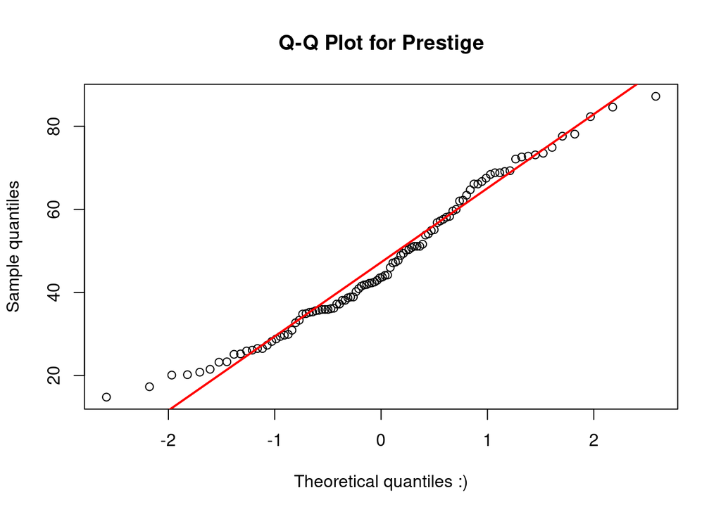

```r
df <- Prestige
df$f.prof <- 0
df$f.prof[df$type == "prof"] <- 1
df$f.prof <- factor(df$f.prof, labels=c("professor, not_professor"))


prestige_mean = mean(df$prestige)
prestige_sd = sd(df$prestige)

#The curve command is linked to the histogram therefore "x" is the same data
#hist(df$prestige, breaks = 12, freq = FALSE, col = "red", main = "Histogram of Prestige vs Normal Curve", xlab = "Prestige", ylab = "Density")
#curve(dnorm(x, mean = prestige_mean, sd = prestige_sd), col = "blue", lwd = 2, add = TRUE)
qqnorm(df$prestige, main="Q-Q Plot for Prestige", xlab= "Theoretical quantiles :)", ylab="Sample quantiles")
qqline(df$prestige, col="red", lwd=2)
```

```r
#Perform a SHAPIRO normality test. H0: prestige is normally distributed
shapiro.test(df$prestige)
```

```
##
##  Shapiro-Wilk normality test
##
## data:  df$prestige
## W = 0.97198, p-value = 0.02875
```

```r
#Perform a Kolmogorov Smirnov general purpose test  (To test between 2 probability distributions)
ks.test(df$prestige, "pnorm", mean=prestige_mean, sd=prestige_sd)
```

```
##
##  Asymptotic one-sample Kolmogorov-Smirnov test
##
## data:  df$prestige
## D = 0.090237, p-value = 0.3773
## alternative hypothesis: two-sided
```

## 2. Mean confidence interval (95%)

Now we are going to check if the mean is equal to 50 with a 95% confidence interval. We also want to see with a 99% confidence interval if the mean is less than 50. Given that we don’t know the true population parameters we will use t-test.

Conclusion: We fail to reject the Null

```r
#Two-sided (Ho: mu = 50)
t.test(df$prestige, conf.level=0.95, mu=50, alternative= "two.sided")
```

```
##
##  One Sample t-test
##
## data:  df$prestige
## t = -1.8589, df = 101, p-value = 0.06595
## alternative hypothesis: true mean is not equal to 50
## 95 percent confidence interval:
##  43.45405 50.21261
## sample estimates:
## mean of x
##  46.83333
```

```r
#One sided (Ho: mu < 50)
t.test(df$prestige, conf.level=0.99, mu=50, alternative="less")
```

```
##
##  One Sample t-test
##
## data:  df$prestige
## t = -1.8589, df = 101, p-value = 0.03297
## alternative hypothesis: true mean is less than 50
## 99 percent confidence interval:
##      -Inf 50.86012
## sample estimates:
## mean of x
##  46.83333
```

```r
#Non-parametric test example W (Great for not normally distributed data)
wilcox.test(df$prestige, mu=50, conf.int=T)
```

```
##
##  Wilcoxon signed rank test with continuity correction
##
## data:  df$prestige
## V = 2054, p-value = 0.0562
## alternative hypothesis: true location is not equal to 50
## 95 percent confidence interval:
##  42.64996 50.10000
## sample estimates:
## (pseudo)median
##       46.39999
```

## 4. Prestige and occupation Relationship

```r
#If its normally distributed then we can test it by hypothesis (ANOVA)
# H0: means of groups defined by its type are equal

#?oneway.test
oneway.test(df$pre ~ df$type)
```

```
##
##  One-way analysis of means (not assuming equal variances)
##
## data:  df$pre and df$type
## F = 117.25, num df = 2.000, denom df = 54.979, p-value < 2.2e-16
```

```r
kruskal.test(df$prestige ~ df$type)
```

```
##
##  Kruskal-Wallis rank sum test
##
## data:  df$prestige by df$type
## Kruskal-Wallis chi-squared = 63.396, df = 2, p-value = 1.713e-14
```

```r
#Binary factor f.prof test

wilcox.test(df$prestige ~ df$f.prof)
```

```
##
##  Wilcoxon rank sum test with continuity correction
##
## data:  df$prestige by df$f.prof
## W = 21, p-value = 4.142e-15
## alternative hypothesis: true location shift is not equal to 0
```

```r
t.test(df$prestige ~ df$f.prof)
```

```
##
##  Welch Two Sample t-test
##
## data:  df$prestige by df$f.prof
## t = -15.035, df = 69.67, p-value < 2.2e-16
## alternative hypothesis: true difference in means between group professor, not_professor1 and group professor, not_professor2 is not equal to 0
## 95 percent confidence interval:
##  -34.19582 -26.18547
## sample estimates:
## mean in group professor, not_professor1 mean in group professor, not_professor2
##                                37.65775                                67.84839
```

```r
# H0: Mean_bluecollar = Mean_whitecollar -> rejection  of H0
# Parametric test
pairwise.t.test(df$prestige, df$type)
```

```
##
##  Pairwise comparisons using t tests with pooled SD
##
## data:  df$prestige and df$type
##
##      bc      prof
## prof < 2e-16 -
## wc   0.0072  9.1e-16
##
## P value adjustment method: holm
```

```r
# H0: Mean_bluecollar = Mean_whitecollar -> rejection  of H0
# Non-parametric test: No assumption about normality of the distribution of data is made
pairwise.wilcox.test(df$prestige, df$type)
```

```
##
##  Pairwise comparisons using Wilcoxon rank sum test with continuity correction
##
## data:  df$prestige and df$type
##
##      bc      prof
## prof 7.3e-13 -
## wc   0.022   7.5e-09
##
## P value adjustment method: holm
```

## 5. Dispersion of prestige

Does the dispersion of prestige depend on the type of occupation? Or on having professional/managerial profile? Formulate and quantify pvalues for testing group variances

```r
#R FORMULA
#LEFT SIDE: DATA VALUES
#RIGHT SIDE: groups

#If normally distributed target -- parametric test on variances
# H0: Sigma1² = Sigma2² = Sigma3² = Sigma² ----> Fail to reject H0
bartlett.test(df$prestige ~ df$type)
```

```
##
##  Bartlett test of homogeneity of variances
##
## data:  df$prestige by df$type
## Bartlett's K-squared = 0.71013, df = 2, p-value = 0.7011
```

```r
#Binary testing on f.prof
# H0: Sprofessor = Snon_professor
var.test(df$prestige ~ df$f.prof)
```

```
##
##  F test to compare two variances
##
## data:  df$prestige by df$f.prof
## F = 1.5119, num df = 70, denom df = 30, p-value = 0.2106
## alternative hypothesis: true ratio of variances is not equal to 1
## 95 percent confidence interval:
##  0.7876572 2.6900187
## sample estimates:
## ratio of variances
##            1.51192
```

```r
#Non-parametric test on variances: No normal distribution for prestige is assumed
# H0: same as past ones --> FAIL TO REJECT H0 IN BOTH CASES
fligner.test(df$prestige ~ df$type)
```

```
##
##  Fligner-Killeen test of homogeneity of variances
##
## data:  df$prestige by df$type
## Fligner-Killeen:med chi-squared = 1.0968, df = 2, p-value = 0.5779
```

```r
fligner.test(df$prestige ~ df$f.prof)
```

```
##
##  Fligner-Killeen test of homogeneity of variances
##
## data:  df$prestige by df$f.prof
## Fligner-Killeen:med chi-squared = 1.7786, df = 1, p-value = 0.1823
```

### Tests Matrix: Parametric/Non-Parametric and Target Sample Variable

[output not shown]